# Лабораторная работа №12

Администрирование локальных сетей

Ибрахим Мохсейн Алькамаль

1032225432@rudn.ru

Российский университет дружбы народов

2026-05-02

# Информация

## Докладчик

- Ибрахим Мохсейн Алькамаль
- Российский университет дружбы народов
- [GitHub](https://github.com/Ebrahimalkamal2027)

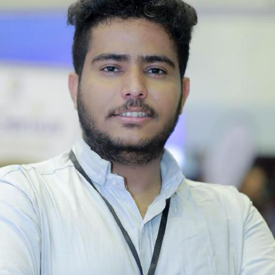

# Лабораторная работа №12. Настройка NAT

## Цель работы

- Освоение настройки доступа локальной сети к Интернет через NAT

# Выполнение лабораторной работы

## Первоначальная настройка маршрутизатора provider-gw-1

- Настроен доступ по паролю для VTY
- Настроен доступ по паролю для консоли
- Установлен enable secret
- Создан пользователь администратора

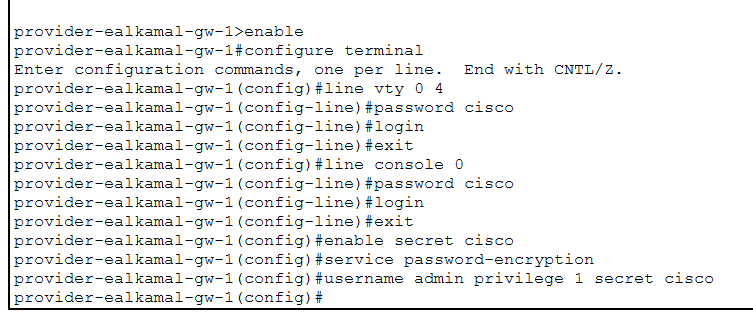

Рисунок 1: Первоначальная настройка маршрутизатора provider-gw-1

## Первоначальная настройка коммутатора provider-sw-1

- Задано имя устройства
- Настроен доступ по VTY и консоли
- Включено шифрование паролей
- Создан пользователь администратора

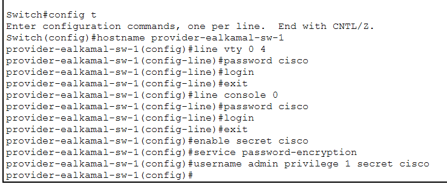

Рисунок 2: Первоначальная настройка коммутатора provider-sw-1

## Настройка интерфейсов маршрутизатора provider-gw-1

- Активирован интерфейс FastEthernet
- Создан подинтерфейс VLAN 4
- Назначен IP-адрес для NAT сети
- Настроен интерфейс выхода в Интернет

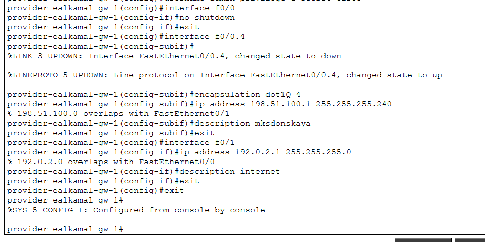

Рисунок 3: Настройка интерфейсов маршрутизатора provider-gw-1

## Настройка интерфейсов коммутатора provider-sw-1

- Интерфейсы переведены в режим trunk
- Создан VLAN 4
- Назначено имя VLAN nat
- Активирован интерфейс VLAN

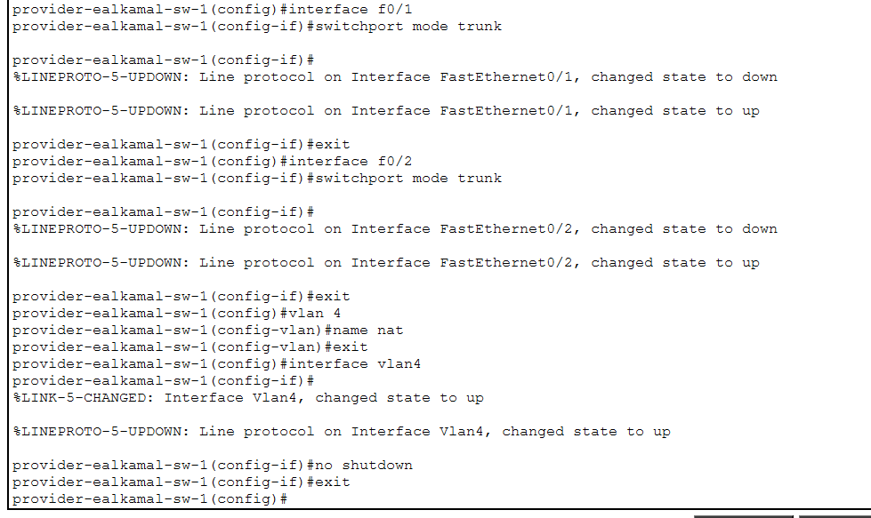

Рисунок 4: Настройка интерфейсов коммутатора provider-sw-1

## Настройка интерфейсов маршрутизатора msk-donskaya-gw-1

- Активирован интерфейс подключения к провайдеру
- Создан подинтерфейс VLAN 4
- Назначен IP-адрес
- Настроен маршрут по умолчанию

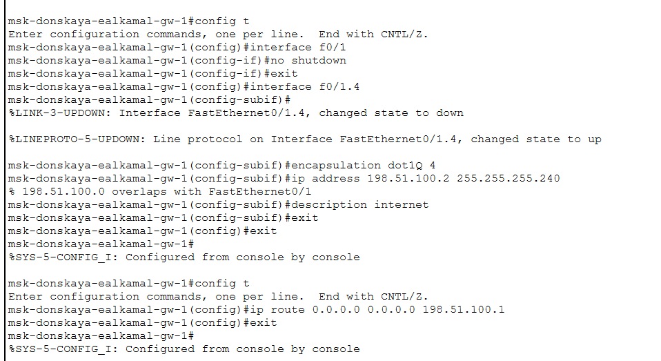

Рисунок 5: Настройка интерфейсов маршрутизатора msk-donskaya-gw-1

## Настройка пула NAT и списка доступа

- Создан пул внешних IP-адресов
- Настроен список доступа NAT
- Заданы правила для VLAN
- Ограничен доступ по условиям

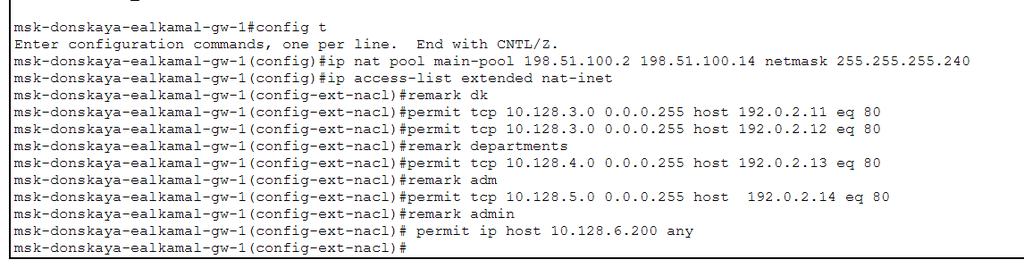

Рисунок 6: Настройка NAT pool и ACL

## Настройка NAT и интерфейсов

- Настроен PAT (overload)
- Применён список доступа
- Назначены inside интерфейсы
- Назначен outside интерфейс

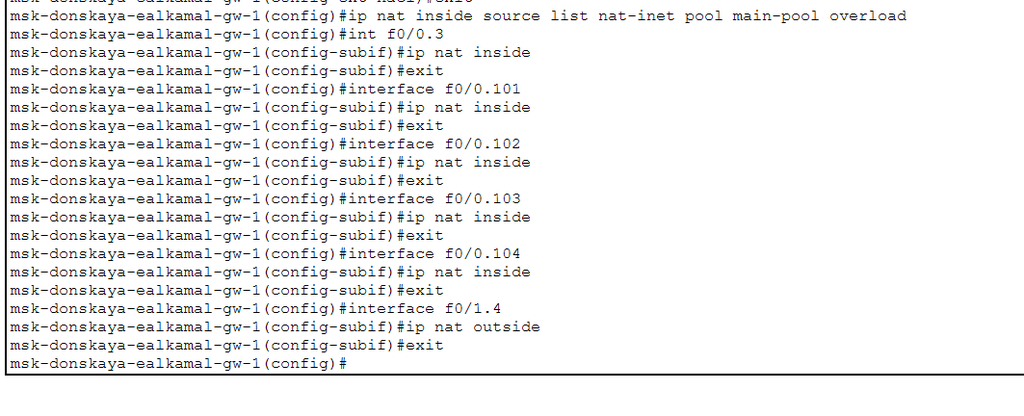

Рисунок 7: Настройка NAT и интерфейсов

## Настройка статических правил NAT

- Настроен доступ к WEB-серверу
- Настроен доступ к файловому серверу
- Настроен доступ к почтовому серверу
- Настроен доступ по RDP

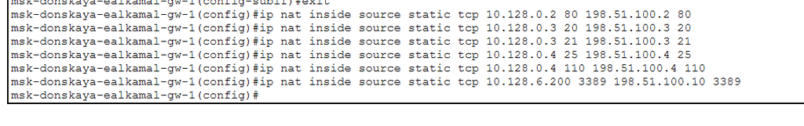

Рисунок 8: Настройка статических NAT правил

## Проверка таблицы трансляций NAT

- Выполнена проверка NAT таблицы
- Обнаружены статические трансляции
- Обнаружены динамические трансляции
- Подтверждена работа NAT

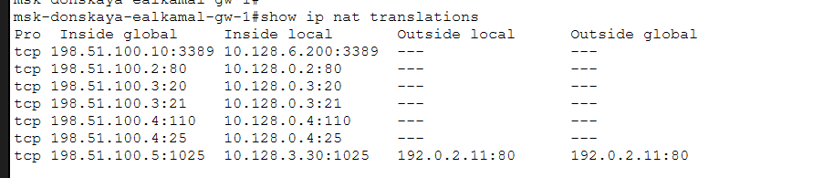

Рисунок 9: Вывод таблицы NAT трансляций

## Проверка статистики NAT

- Проверено количество трансляций
- Проверено использование пула
- Обнаружены активные соединения

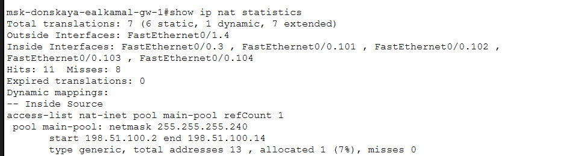

Рисунок 10: Вывод статистики NAT

## Проверка списков доступа

- Проверены ACL правила
- Подтверждена фильтрация трафика
- Проверено соответствие условиям

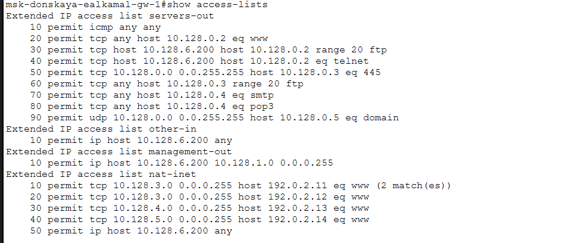

Рисунок 11: Вывод списков доступа

## Проверка таблицы маршрутизации

- Проверен маршрут по умолчанию
- Проверены подключённые сети
- Подтверждена корректная маршрутизация

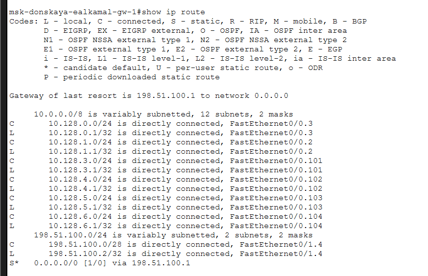

Рисунок 12: Вывод таблицы маршрутизации msk-donskaya-gw-1

## Проверка состояния интерфейсов

- Проверено состояние интерфейсов
- Подтверждена их активность
- Проверена IP-адресация

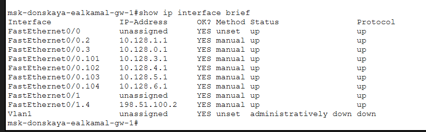

Рисунок 13: Вывод состояния интерфейсов

## Проверка маршрутизации на стороне провайдера

- Проверена таблица маршрутизации
- Обнаружен маршрут к внутренним сетям
- Подтверждена доступность сети

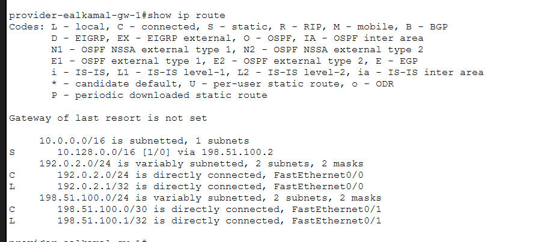

Рисунок 14: Вывод таблицы маршрутизации provider-gw-1

# Выводы

- Настроен доступ к Интернет через NAT
- Реализован PAT с использованием пула адресов
- Ограничен доступ для VLAN по условиям
- Настроены статические правила NAT
- Подтверждена корректная работа сети